# Example prediction workflow

Lofton, M.E.

2025-03-27

## Workflow overview

This RMarkdown document contains a complete chlorophyll-a prediction workflow for an ARIMA model fit using the `fable` package in R. All intermediate files and output of the workflow will be written to the `example_workflow_output` folder in the `multi-model-chla-prediction` GitHub repository. The steps of the workflow are:

1. Download and write a local copy of lake data from Environmental Data Initiative repository
2. Download lake data from the Virginia EcoForecast Reservoir Analysis forecasting challenge and format lake data before model training to meet model input data formatting requirements
3. Train ARIMA model using data from 2018-08-06 to 2021-12-31 and visualize model diagnostics
4. Generate chlorophyll-a predictions from 1-35 days into the future for every day from 2022-01-01 to 2023-11-26
5. Visualize an example chlorophyll-a prediction and assess predictive skill of the ARIMA model
6. Additional guidelines for those who wish to run this workflow for a different model

Several custom functions are sourced throughout the workflow. Function metadata for these functions can be found in the source files for each function.

First, install and load packages.

```r
if (!require("pacman")) install.packages("pacman")
pacman::p_load(tidyverse, lubridate, ggpubr, data.table, zoo, fable, viridis, knitr)
```

## 1. Download and write a local copy of lake data from Environmental Data Initiative repository

```r
#Download and read in data from Falling Creek Reservoir stored in the
#Environmental Data Initiative Repository

#Data needed:
#'water chemistry (SRP, DIN)

options(timeout=10000)

# chemistry
inUrl1  <- "https://portal.edirepository.org/nis/dataviewer?packageid=edi.199.12&entityid=a33a5283120c56e90ea414e76d5b7ddb"
infile1 <- paste0("./example_workflow_output/chemistry_2013_2023.csv")
try(download.file(inUrl1,infile1,method="curl"))
if (is.na(file.size(infile1))) download.file(inUrl1,infile1,method="auto")
```

## 2. Download lake data from the Virginia Ecoforecast Reservoir Analysis forecasting challenge and format lake data before model training to meet model input data formatting requirements

```r
# Source script with function to format data for ARIMA model and to format chloropyll-a observations for comparison to model
source("./code/function_library/format_data/format_data_ARIMA.R")
source("./code/function_library/format_data/format_chla_obs.R")

# Run functions
dat_ARIMA <- format_data_ARIMA(filepath_chemistry = "./example_workflow_output/chemistry_2013_2023.csv",
                              res_url = "https://renc.osn.xsede.org/bio230121-bucket01/vera4cast/targets/project_id=vera4cast/duration=P1D/daily-insitu-targets.csv.gz",
                              inf_url = "https://renc.osn.xsede.org/bio230121-bucket01/vera4cast/targets/project_id=vera4cast/duration=P1D/daily-inflow-targets.csv.gz",
                              met_url = "https://renc.osn.xsede.org/bio230121-bucket01/vera4cast/targets/project_id=vera4cast/duration=P1D/daily-met-targets.csv.gz",
                              start_date = "2018-08-06",
                              end_date = "2023-12-31",
                              include_drivers = TRUE)

obs <- format_chla_obs(res_url = "https://renc.osn.xsede.org/bio230121-bucket01/vera4cast/targets/project_id=vera4cast/duration=P1D/daily-insitu-targets.csv.gz")

# Write formatted data to file
write.csv(obs, "./example_workflow_output/chla_obs.csv",row.names = FALSE)
write.csv(dat_ARIMA, "./example_workflow_output/ARIMA.csv",row.names = FALSE)
```

## 3. Train ARIMA model using data from 2018-08-06 to 2021-12-31 and assess model goodness-of-fit

```r
# Source script with function to format data for ARIMA model
source("./code/function_library/fit_models/fit_ARIMA.R")

# Read in formatted ARIMA data
dat_ARIMA <- read_csv("./example_workflow_output/ARIMA.csv")

# Run fit_ARIMAs function; this will fit models both with and without environmental variables as drivers
fit_ARIMAs <- fit_ARIMAs(data = dat_ARIMA, cal_dates = c("2018-08-06","2021-12-31"))
```

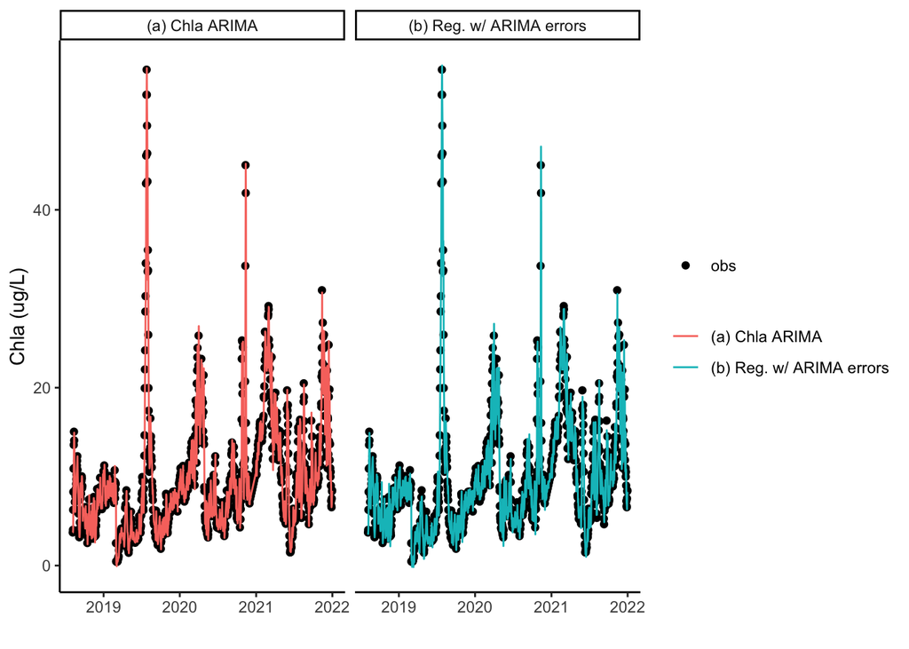

```r
# Generate plot of model fits
fit_ARIMAs$plot
```

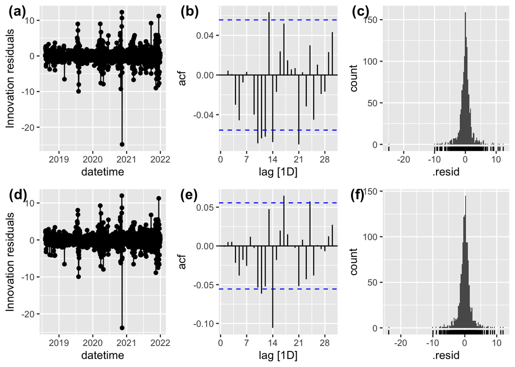

```r
# Generate plot of model diagnostics
ARIMA_diagnostics <- ggarrange(plotlist = c(fit_ARIMAs$diagnostics_chla_only, fit_ARIMAs$diagnostics_drivers),
                              labels = c("(a)","(b)","(c)","(d)","(e)","(f)"))
ARIMA_diagnostics
```

```r
# View table of model parameters
knitr::kable(fit_ARIMAs$model_params)
```

| .model | term | estimate | std.error | statistic | p.value |
| --- | --- | --- | --- | --- | --- |
| (a) Chla ARIMA | ar1 | -0.72 | 0.09 | -8.33 | 0.00 |
| (a) Chla ARIMA | ma1 | 0.80 | 0.09 | 8.89 | 0.00 |
| (a) Chla ARIMA | ma2 | 0.06 | 0.04 | 1.47 | 0.14 |
| (a) Chla ARIMA | ma3 | -0.10 | 0.03 | -3.04 | 0.00 |
| (a) Chla ARIMA | sma1 | -0.05 | 0.03 | -1.43 | 0.15 |
| (b) Reg. w/ ARIMA errors | ar1 | -0.75 | 0.06 | -11.66 | 0.00 |
| (b) Reg. w/ ARIMA errors | ma1 | 0.85 | 0.07 | 12.19 | 0.00 |
| (b) Reg. w/ ARIMA errors | ma2 | 0.09 | 0.04 | 2.21 | 0.03 |
| (b) Reg. w/ ARIMA errors | ma3 | -0.09 | 0.03 | -2.89 | 0.00 |
| (b) Reg. w/ ARIMA errors | AirTemp_C_mean | 0.04 | 0.02 | 2.42 | 0.02 |
| (b) Reg. w/ ARIMA errors | PAR_umolm2s_mean | 0.00 | 0.00 | -3.90 | 0.00 |
| (b) Reg. w/ ARIMA errors | WindSpeed_ms_mean | -0.12 | 0.07 | -1.62 | 0.11 |
| (b) Reg. w/ ARIMA errors | Flow_cms_mean | 31.96 | 5.88 | 5.44 | 0.00 |
| (b) Reg. w/ ARIMA errors | Temp_C_mean | -0.56 | 0.12 | -4.50 | 0.00 |
| (b) Reg. w/ ARIMA errors | LightAttenuation_Kd | 0.13 | 0.56 | 0.23 | 0.81 |
| (b) Reg. w/ ARIMA errors | DIN_ugL | -0.02 | 0.01 | -3.07 | 0.00 |
| (b) Reg. w/ ARIMA errors | SRP_ugL | 0.13 | 0.13 | 0.95 | 0.34 |

## 4. Generate chlorophyll-a predictions from 1-35 days into the future for every day from 2022-01-01 to 2023-11-26

```r
# Source script with function to format data for ARIMA model
source("./code/function_library/predict/fableARIMA.R")

# Read in formatted ARIMA data
dat_ARIMA <- read_csv("./example_workflow_output/ARIMA.csv")

# Set prediction window and forecast horizon
pred_dates <- seq.Date(from = as.Date("2022-01-01"), to = as.Date("2023-11-26"), by = "day")
forecast_horizon = 35

# Generate 1-35-day-ahead predictions for every day from 2022-01-01 to 2023-11-26; in this case, we are generating predictions using an ARIMA model that uses all environmental variables as regessors
pred_ARIMA_Drivers <- fableARIMA(data = dat_ARIMA,
                pred_dates = pred_dates,
                forecast_horizon = forecast_horizon,
                include_drivers = TRUE)

write.csv(pred_ARIMA_Drivers, "./example_workflow_output/validation_output.csv", row.names = FALSE)
```

## 5. Visualize an example chlorophyll-a prediction and assess predictive skill of the ARIMA model

```r
# Read in model predictions
out <- read_csv("./example_workflow_output/validation_output.csv") %>%
  mutate(model_type = "data-driven")
unique(out$model_id)
```

```
## [1] "ARIMA"
```

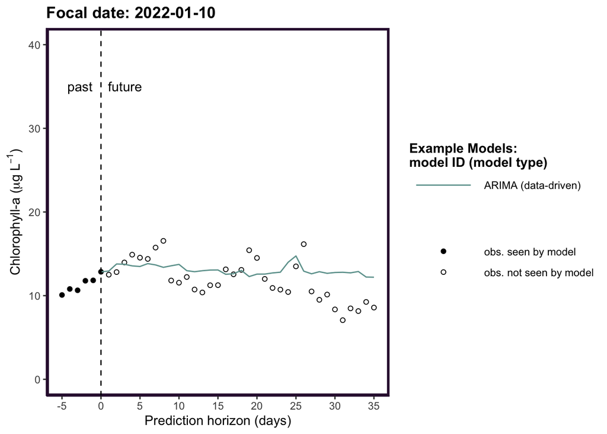

```r
# Read in observed lake data
obs <- read_csv("./example_workflow_output/chla_obs.csv")
input <- read_csv("./example_workflow_output/ARIMA.csv")

# Source plotting functions
source("./code/function_library/visualization/ExamplePrediction.R")
source("./code/function_library/visualization/SkillVsHorizon.R")

#Set arguments for plotting functions
forecast_horizon = 35
pred_dates <- seq.Date(from = as.Date("2022-01-01"), to = as.Date("2023-11-26"), by = "day")
plot_cols <- viridis(6, option = "turbo")
focal_date = c("2022-01-10")

example_pred_plot <- ExamplePrediction(observations = obs,
                         model_output = out,
                         reference_datetime = focal_date,
                         forecast_horizon = forecast_horizon,
                         model_ids = c("ARIMA"),
                         show_legend = TRUE,
                         sub_panel_label = "Focal date: ",
                         rect_color = plot_cols[1],
                         ylim_values = c(0,40),
                         show_shapes = FALSE)
example_pred_plot
```

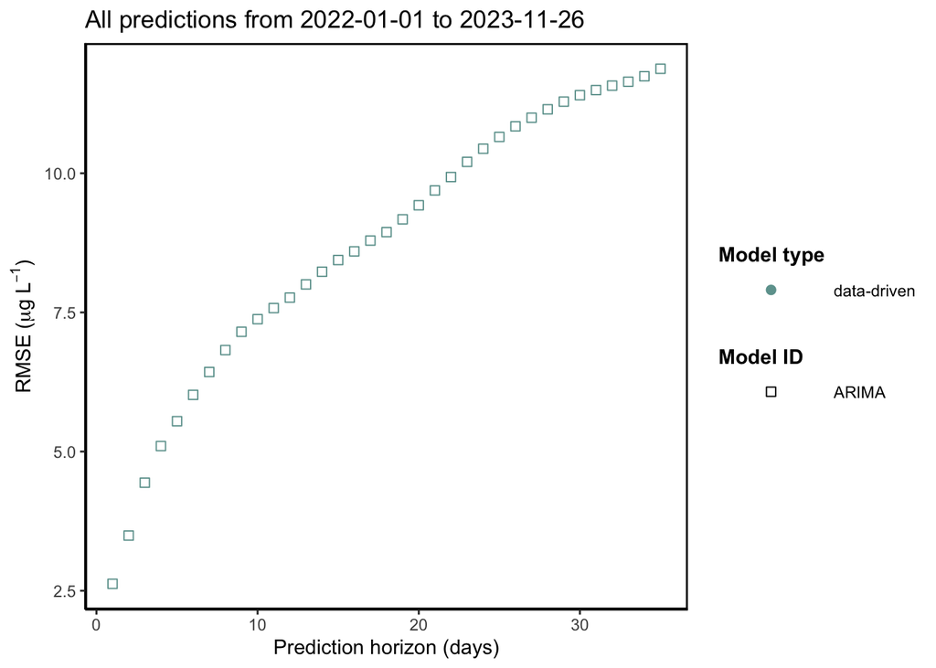

```r
skill_vs_horizon_plot <- SkillVsHorizon(observations = obs,
                      model_output = out,
                      forecast_horizon = 35,
                      model_ids = c("ARIMA"),
                      best_models_only = FALSE,
                      viz_dates = pred_dates,
                      plot_title = "All predictions from 2022-01-01 to 2023-11-26",
                      viz_metric = "rmse",
                      show_legend = TRUE,
                      make_combined_bestmodel_legend = FALSE,
                      add_vline = FALSE,
                      vline_intercept = 26,
                      combined_var = "none",
                      show_null_model = FALSE,
                      fixed_ylim = FALSE)
skill_vs_horizon_plot
```

## 6. Additional guidelines for those who wish to run this workflow for a different model

For many of the other models in this analysis, the full prediction workflow can be run by sourcing the relevant custom functions for that model rather than the ARIMA model. For example, for the TSLM model, the user would source the `./code/function_library/format_data/format_data_TSLM.R` function in step 2, the `./code/function_library/fit_models/fit_TSLM.R` in step 3, and so on.

For the code relevant for each model, users can look in the `workflow_scripts` folder and find the script corresponding to each step in this example prediction workflow. For example, to find code to generate predictions for the TSLM model, the user would open the file `./code/workflow_scripts/04_predict.R` and look through that file for code relevant to the TSLM model.

There are two models for which workflows are more complex: the LSTM model and the GLM-AED model. Due to high model structural complexity, long run times, and a substantial number of dependencies, the workflows for both of these models were run via high-performance computing in containerized environments. Specifically, the LSTM model was run using a slightly modified version of the `ml-verse` container which can be downloaded at `https://hub.docker.com/repository/docker/melofton/ml-verse/general`, and the GLM-AED model was run using a container developed by R. Quinn Thomas for the Forecasting Lake and Reservoir Ecosystems (FLARE) platform which can be downloaded at `https://hub.docker.com/layers/rqthomas/flare-rocker/4.4/images/sha256-3f6c7df54b67dc7bd4dbec54f69edf8068c1a786c831381e1907b5fb33678d3c`.

We encourage users to contact the corresponding author (Mary Lofton; melofton@vt.edu) with any questions related to implementing or reproducing model and prediction workflows.